# Linear models in R

# 1 Loading packages

```r
## To install needed CRAN packages:
#
# install.packages("tidyverse")
# install.packages("multcomp")
#
## To install needed Bioconductor packages:
#
# source("https://bioconductor.org/biocLite.R")
# biocLite(c("limma", "edgeR"))
#
```

```r
library(MASS)       # ginv -- coefficient estimation
library(splines)    # ns, bs -- spline curves
library(multcomp)   # glht -- linear hypotheses
library(edgeR)      # cpm, etc -- RNA-Seq normalization
library(limma)      # lmFit, etc -- fitting many models
library(tidyverse)  # working with data frames, plotting
```

Much of what we will be using is built into R without loading any packages.

# 2 Single numerical predictor

The age (year) and height (cm) of 10 people has been measured. We want a model that can predict height based on age.

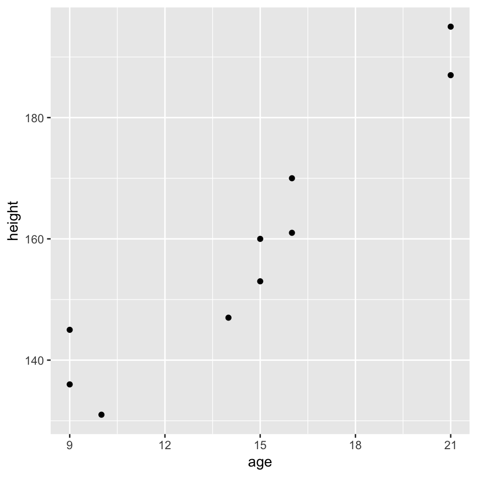

```r
people <- read_csv(
    "age, height
      10,    131
      14,    147
      16,    161
       9,    136
      16,    170
      15,    160
      15,    153
      21,    187
       9,    145
      21,    195")

ggplot(people, aes(x=age, y=height)) + geom_point()
```

```r
fit <- lm(height ~ 1+age, data=people)

fit
```

```
##
## Call:
## lm(formula = height ~ 1 + age, data = people)
##
## Coefficients:
## (Intercept)          age
##      92.612        4.513
```

- This is not normal addition, it’s special formula notation.
- We can “add” any number of predictors.
- “1” denotes an intercept term. This is actually implictly included even if you leave it out.

```r
lm(height ~   age, data=people)  # Implicit intercept term
```

```
##
## Call:
## lm(formula = height ~ age, data = people)
##
## Coefficients:
## (Intercept)          age
##      92.612        4.513
```

```r
lm(height ~ 0+age, data=people)  # Use 0 or -1 to omit
```

```
##
## Call:
## lm(formula = height ~ 0 + age, data = people)
##
## Coefficients:
##   age
## 10.39
```

Coefficients are extracted with `coef`:

```r
coef(fit)
```

```
## (Intercept)         age
##   92.611502    4.512911
```

The residual standard deviation is extracted with `sigma`:

```r
sigma(fit)
```

```
## [1] 7.263536
```

Behind the scenes a matrix of predictors has been produced from the formula notation `~ 1+age`. We can examine it explicitly:

[output not shown]

`model.matrix` can be used without first calling `lm`.

```r
model.matrix(~ 1+age, data=people)
```

```
##    (Intercept) age
## 1            1  10
## 2            1  14
## 3            1  16
## 4            1   9
## 5            1  16
## 6            1  15
## 7            1  15
## 8            1  21
## 9            1   9
## 10           1  21
## attr(,"assign")
## [1] 0 1
```

n=10 observations minus p=2 columns in the model matrix leaves 8 residual degrees of freedom:

```r
df.residual(fit)
```

```
## [1] 8
```

## 2.1 Prediction

`predict` predicts. By default it produces predictions on the original dataset.

```r
predict(fit)
```

```
##        1        2        3        4        5        6        7        8
## 137.7406 155.7923 164.8181 133.2277 164.8181 160.3052 160.3052 187.3826
##        9       10
## 133.2277 187.3826
```

```r
predict(fit, interval="confidence")
```

```
##         fit      lwr      upr
## 1  137.7406 129.8100 145.6712
## 2  155.7923 150.4399 161.1446
## 3  164.8181 159.2250 170.4111
## 4  133.2277 124.3009 142.1545
## 5  164.8181 159.2250 170.4111
## 6  160.3052 154.9836 165.6267
## 7  160.3052 154.9836 165.6267
## 8  187.3826 177.6105 197.1547
## 9  133.2277 124.3009 142.1545
## 10 187.3826 177.6105 197.1547
```

We can also calculate predictions manually.

```r
# Prediction for a 15-year old
x <- c(1, 15)
beta <- coef(fit)
sum(x * beta)
```

```
## [1] 160.3052
```

```r
# Prediction for all original data
X <- model.matrix(fit)
as.vector( X %*% beta )
```

```
##  [1] 137.7406 155.7923 164.8181 133.2277 164.8181 160.3052 160.3052
##  [8] 187.3826 133.2277 187.3826
```

`predict` can be used with new data.

```r
new_people <- data_frame(age=5:25)
predict(fit, new_people)
```

```
##        1        2        3        4        5        6        7        8
## 115.1761 119.6890 124.2019 128.7148 133.2277 137.7406 142.2535 146.7664
##        9       10       11       12       13       14       15       16
## 151.2793 155.7923 160.3052 164.8181 169.3310 173.8439 178.3568 182.8697
##       17       18       19       20       21
## 187.3826 191.8955 196.4085 200.9214 205.4343
```

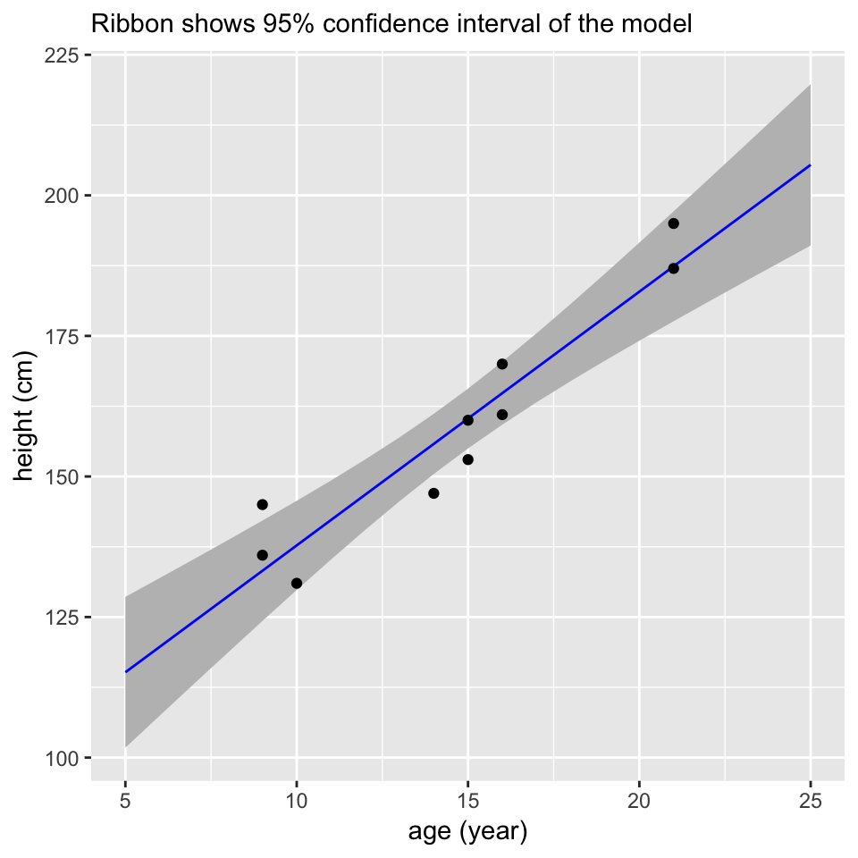

```r
new_predictions <- cbind(
    new_people,
    predict(fit, new_people, interval="confidence"))

ggplot() +
    geom_ribbon(aes(x=age, ymin=lwr, ymax=upr), data=new_predictions, fill="grey") +
    geom_line(aes(x=age, y=fit), data=new_predictions, color="blue") +
    geom_point(aes(x=age, y=height), data=people) +
    labs(y="height (cm)", x="age (year)",
         subtitle="Ribbon shows 95% confidence interval of the model")
```

If you have ever used `geom_smooth`, it should now be a little less mysterious.

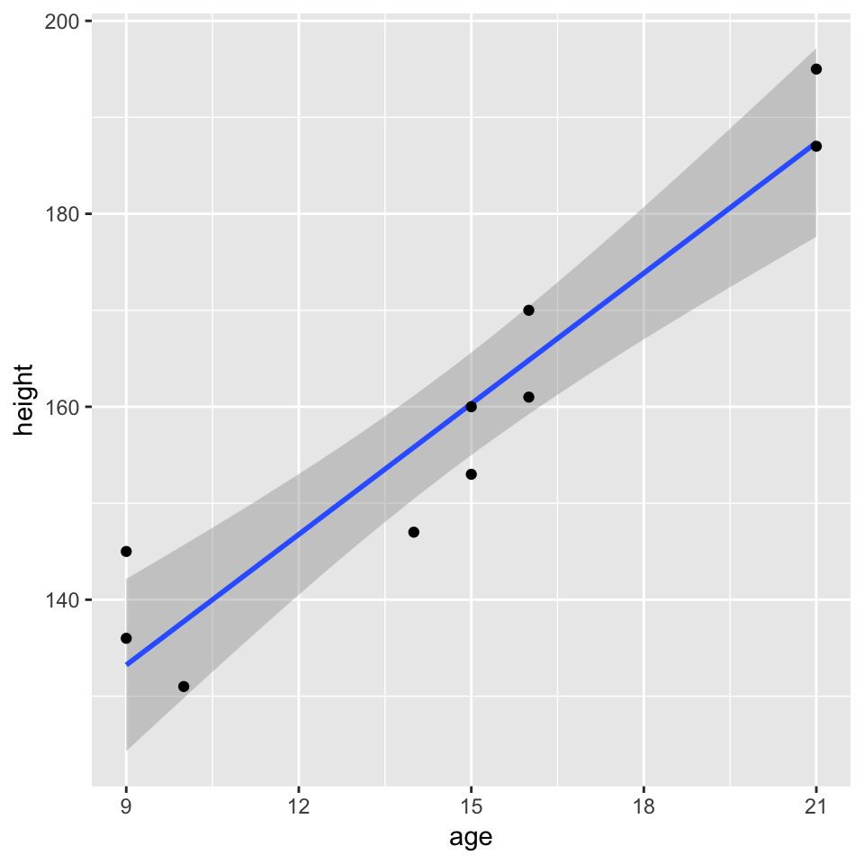

```r
ggplot(people, aes(x=age, y=height)) + geom_smooth(method="lm") + geom_point()
```

## 2.2 Residuals

The residuals are the differences between predicted and actual values.

```r
residuals(fit)
```

```
##          1          2          3          4          5          6
## -6.7406103 -8.7922535 -3.8180751  2.7723005  5.1819249 -0.3051643
##          7          8          9         10
## -7.3051643 -0.3826291 11.7723005  7.6173709
```

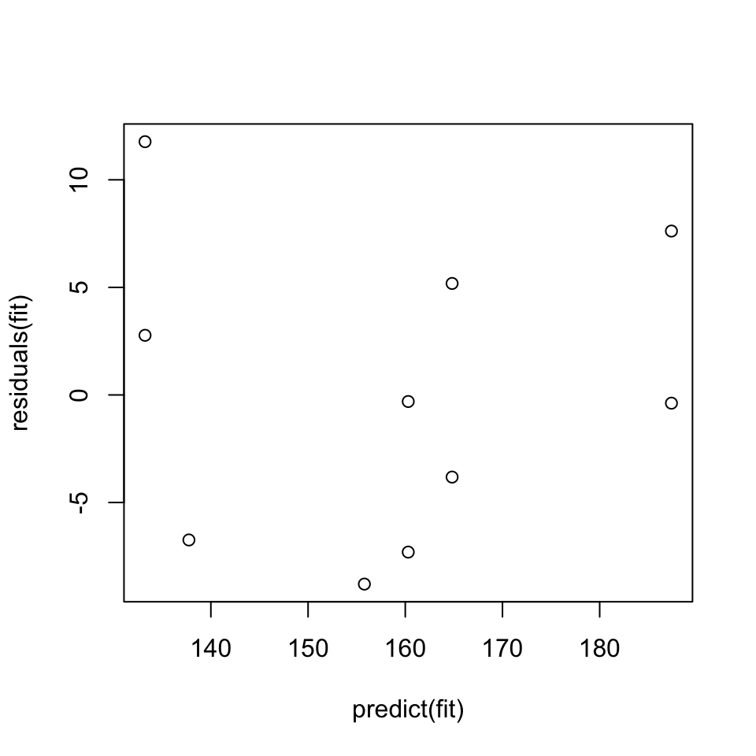

```r
plot(predict(fit), residuals(fit))
```

Residuals should be close to normally distributed.

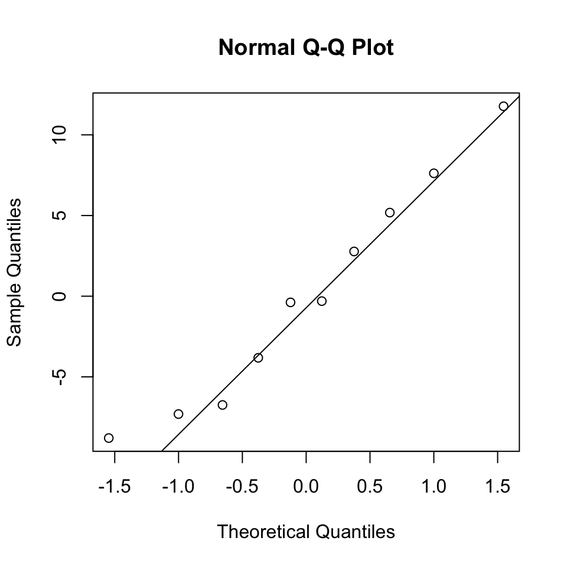

```r
qqnorm(residuals(fit))
qqline(residuals(fit))
```

`plot(fit)` produces a series of more sophisticated diagnostic plots.

```r
plot(fit)
```

[output not shown]

## 2.3 Comparing nested models

The `anova( )` function performs an F-test to compare two models. ANOVA means ANalysis Of VAriance, because the test compares the residual variances of the two models.

The simpler model formula must *nest* inside the more complex model formula, or the test will be invalid: any model possible with the simpler formula must have an equivalent with the more complex formula. The test tells us if we have grounds to reject the simpler model formula.

```r
fit_noslope <- lm(height ~ 1, data=people)
anova(fit_noslope, fit)
```

```
## Analysis of Variance Table
##
## Model 1: height ~ 1
## Model 2: height ~ 1 + age
##   Res.Df    RSS Df Sum of Sq      F    Pr(>F)
## 1      9 3892.5
## 2      8  422.1  1    3470.4 65.779 3.956e-05 ***
## ---
## Signif. codes:  0 '***' 0.001 '**' 0.01 '*' 0.05 '.' 0.1 ' ' 1
```

```r
fit_nointercept <- lm(height ~ 0+age, data=people)
anova(fit_nointercept, fit)
```

```
## Analysis of Variance Table
##
## Model 1: height ~ 0 + age
## Model 2: height ~ 1 + age
##   Res.Df    RSS Df Sum of Sq      F    Pr(>F)
## 1      9 6770.9
## 2      8  422.1  1    6348.8 120.34 4.236e-06 ***
## ---
## Signif. codes:  0 '***' 0.001 '**' 0.01 '*' 0.05 '.' 0.1 ' ' 1
```

`summary( )` is a quick and dirty way to compare a model to models with each of the terms dropped in turn.

```r
summary(fit)
```

```
##
## Call:
## lm(formula = height ~ 1 + age, data = people)
##
## Residuals:
##     Min      1Q  Median      3Q     Max
## -8.7923 -6.0100 -0.3439  4.5795 11.7723
##
## Coefficients:
##             Estimate Std. Error t value Pr(>|t|)
## (Intercept)  92.6115     8.4424   10.97 4.24e-06 ***
## age           4.5129     0.5564    8.11 3.96e-05 ***
## ---
## Signif. codes:  0 '***' 0.001 '**' 0.01 '*' 0.05 '.' 0.1 ' ' 1
##
## Residual standard error: 7.264 on 8 degrees of freedom
## Multiple R-squared:  0.8916, Adjusted R-squared:  0.878
## F-statistic: 65.78 on 1 and 8 DF,  p-value: 3.956e-05
```

Note that the p-values match those from the calls to `anova( )`.

Finally, `confint( )` gives confidence intervals for coefficients. If a coefficient had p-value 0.05 in the above tests, the confidence interval would just touch zero.

```r
confint(fit)
```

```
##                 2.5 %     97.5 %
## (Intercept) 73.143293 112.079712
## age          3.229773   5.796049
```

### 2.3.1 Question

```r
y <- c(5,3,2,4,1)
fit0 <- lm(y ~ 0)
fit1 <- lm(y ~ 1)
anova(fit0, fit1)
```

1. Describe the null hypothesis (fit0).
2. Describe the alternative hypothesis (fit1).
3. What have we shown with this test?

# 3 Single factor predictor

Consider a simple experiment where two treatments are compared with a control group. This is called a one-way ANOVA experiment. This is another usage of the term ANOVA! The F-test we just used was developed by Fisher in the context of this type of model.

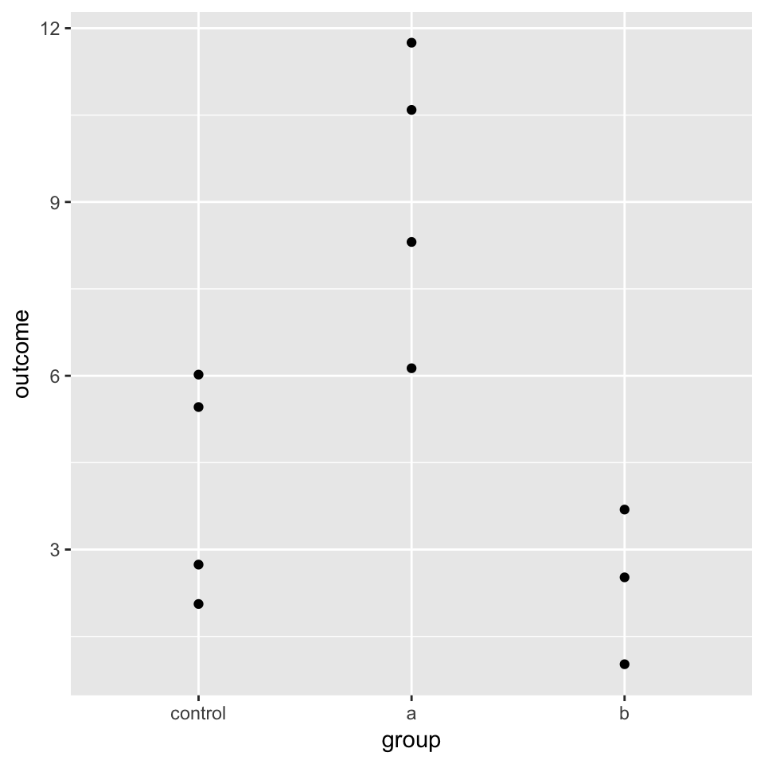

```r
outcomes <- read_csv(
    "group,    outcome
     control,  5.46
     control,  2.06
     control,  2.74
     control,  6.02
     a,        8.31
     a,        11.75
     a,        6.13
     a,        10.59
     b,        1.02
     b,        3.69
     b,        2.52")

outcomes$group <- factor(outcomes$group, c("control", "a", "b"))

ggplot(outcomes, aes(x=group, y=outcome)) + geom_point()
```

```r
outfit <- lm(outcome ~ group, data=outcomes)
outfit
```

```
##
## Call:
## lm(formula = outcome ~ group, data = outcomes)
##
## Coefficients:
## (Intercept)       groupa       groupb
##       4.070        5.125       -1.660
```

```r
df.residual(outfit)
```

```
## [1] 8
```

```r
sigma(outfit)
```

```
## [1] 2.054802
```

## 3.1 Meanings of the coefficients

```r
model.matrix(outfit)
```

```
##    (Intercept) groupa groupb
## 1            1      0      0
## 2            1      0      0
## 3            1      0      0
## 4            1      0      0
## 5            1      1      0
## 6            1      1      0
## 7            1      1      0
## 8            1      1      0
## 9            1      0      1
## 10           1      0      1
## 11           1      0      1
## attr(,"assign")
## [1] 0 1 1
## attr(,"contrasts")
## attr(,"contrasts")$group
## [1] "contr.treatment"
```

It’s important to understand how the factor has been encoded. It’s a bit weird, but it’s a system that extends well to models with multiple factors. The factor is encoded as “indicator variables” for all but the first level in the factor (“one-hot encoding”). This means:

- `(Intercept)` represents the average for the control group
- `groupa` is the difference from the control to group “a”
- `groupb` is the difference from the control to group “b”

If this becomes confusing, it’s possible to directly examine how coefficients are fitted, which is by multiplying by the “Moore-Penrose generalized inverse” of the model matrix.

```r
library(MASS)
X <- model.matrix(~ group, data=outcomes)
ginv(X) %>% round(2)
```

```
##       [,1]  [,2]  [,3]  [,4] [,5] [,6] [,7] [,8] [,9] [,10] [,11]
## [1,]  0.25  0.25  0.25  0.25 0.00 0.00 0.00 0.00 0.00  0.00  0.00
## [2,] -0.25 -0.25 -0.25 -0.25 0.25 0.25 0.25 0.25 0.00  0.00  0.00
## [3,] -0.25 -0.25 -0.25 -0.25 0.00 0.00 0.00 0.00 0.33  0.33  0.33
```

```r
ginv(X) %*% outcomes$outcome   #Confirm estimates are the same
```

```
##        [,1]
## [1,]  4.070
## [2,]  5.125
## [3,] -1.660
```

## 3.2 F test

An F test comparing to a null hypothesis model with just an intercept term tells us if there are any detectable differences between groups.

```r
outfit_null <- lm(outcome ~ 1, data=outcomes)
anova(outfit_null, outfit)
```

```
## Analysis of Variance Table
##
## Model 1: outcome ~ 1
## Model 2: outcome ~ group
##   Res.Df     RSS Df Sum of Sq      F   Pr(>F)
## 1     10 125.210
## 2      8  33.778  2    91.432 10.828 0.005296 **
## ---
## Signif. codes:  0 '***' 0.001 '**' 0.01 '*' 0.05 '.' 0.1 ' ' 1
```

## 3.3 Comparing pairs of levels

What about between specific pairs of groups? `summary( )` (and `confint( )`) give us two of the answers, “a” vs “control” and “b” vs “control”.

```r
summary(outfit)
```

```
##
## Call:
## lm(formula = outcome ~ group, data = outcomes)
##
## Residuals:
##    Min     1Q Median     3Q    Max
## -3.065 -1.360  0.110  1.393  2.555
##
## Coefficients:
##             Estimate Std. Error t value Pr(>|t|)
## (Intercept)    4.070      1.027   3.961  0.00417 **
## groupa         5.125      1.453   3.527  0.00776 **
## groupb        -1.660      1.569  -1.058  0.32106
## ---
## Signif. codes:  0 '***' 0.001 '**' 0.01 '*' 0.05 '.' 0.1 ' ' 1
##
## Residual standard error: 2.055 on 8 degrees of freedom
## Multiple R-squared:  0.7302, Adjusted R-squared:  0.6628
## F-statistic: 10.83 on 2 and 8 DF,  p-value: 0.005296
```

```r
confint(outfit)
```

```
##                 2.5 %   97.5 %
## (Intercept)  1.700809 6.439191
## groupa       1.774458 8.475542
## groupb      -5.278999 1.958999
```

What about “b” vs “a”? For this we need a linear hypothesis test.

```r
coef(outfit)[3] - coef(outfit)[2]
```

```
## groupb
## -6.785
```

```r
library(multcomp)

K <- rbind(c(0, -1, 1))
K %*% coef(outfit)
```

```
##        [,1]
## [1,] -6.785
```

```r
result <- glht(outfit, K)
summary(result)
```

```
##
##   Simultaneous Tests for General Linear Hypotheses
##
## Fit: lm(formula = outcome ~ group, data = outcomes)
##
## Linear Hypotheses:
##        Estimate Std. Error t value Pr(>|t|)
## 1 == 0   -6.785      1.569  -4.323  0.00253 **
## ---
## Signif. codes:  0 '***' 0.001 '**' 0.01 '*' 0.05 '.' 0.1 ' ' 1
## (Adjusted p values reported -- single-step method)
```

```r
confint(result)
```

```
##
##   Simultaneous Confidence Intervals
##
## Fit: lm(formula = outcome ~ group, data = outcomes)
##
## Quantile = 2.306
## 95% family-wise confidence level
##
##
## Linear Hypotheses:
##        Estimate lwr      upr
## 1 == 0  -6.7850 -10.4040  -3.1660
```

`multcomp` can be given multiple rows to test in `K`. In this case, by default, it does a multiple testing correction to maintain the Family-Wise Error Rate using a generalization of Tukey’s Honestly Significant Differences.

## 3.4 Factor model without an intercept

There’s a further rule to learn about how R deals with factors in linear models. If the intercept is omitted, R produces a predictor for each level in the factor (rather than all but the first).

```r
outfit2 <- lm(outcome ~ 0+group, data=outcomes)
outfit2
```

```
##
## Call:
## lm(formula = outcome ~ 0 + group, data = outcomes)
##
## Coefficients:
## groupcontrol        groupa        groupb
##        4.070         9.195         2.410
```

```r
model.matrix(outfit2)
```

```
##    groupcontrol groupa groupb
## 1             1      0      0
## 2             1      0      0
## 3             1      0      0
## 4             1      0      0
## 5             0      1      0
## 6             0      1      0
## 7             0      1      0
## 8             0      1      0
## 9             0      0      1
## 10            0      0      1
## 11            0      0      1
## attr(,"assign")
## [1] 1 1 1
## attr(,"contrasts")
## attr(,"contrasts")$group
## [1] "contr.treatment"
```

This fit is equivalent to the original `outfit`, but the coefficients have different meanings.

### 3.4.1 Question

1. What are the meanings of the three coefficients in this alternative model?
2. What would be the linear hypotheses to test differences between each pair of groups?

# 4 Gene expression example

Tooth growth in mouse embryos is studied using RNA-Seq. The RNA expression levels of several genes are examined in the cells that form the upper and lower first molars, in eight individual mouse embryos that have been dissected after different times of embryo development. The measurements are in terms of “Reads Per Million”, essentially the fraction of RNA in each sample belonging to each gene, times 1 million.

(This data was extracted from ARCHS4 (https://amp.pharm.mssm.edu/archs4/). In the Gene Expression Omnibus it is entry GSE76316. The sample descriptions in GEO seem to be out of order, but reading the associated paper and the genes they talk about I *think* I have the correct order of samples!)

```r
teeth <- read_csv("data/linearModels/teeth.csv")
teeth$tooth <- factor(teeth$tooth, c("lower","upper"))
teeth$mouse <- factor(teeth$mouse)
```

It will be convenient to have a quick way to examine different genes and different models with this data.

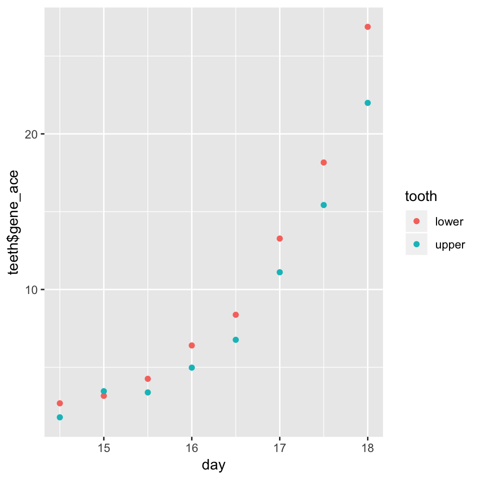

```r
# A convenience to examine different model fits
more_data <- expand.grid(
    day=seq(14.3,18.2,by=0.01),
    tooth=as_factor(c("lower","upper")))

look <- function(y, fit=NULL) {
    p <- ggplot(teeth,aes(x=day,group=tooth))
    if (!is.null(fit)) {
        more_ci <- cbind(
            more_data,
            predict(fit, more_data, interval="confidence"))
        p <- p +
            geom_ribbon(data=more_ci, aes(ymin=lwr,ymax=upr),alpha=0.1) +
            geom_line(data=more_ci,aes(y=fit,color=tooth))
    }
    p + geom_point(aes(y=y,color=tooth)) +
        labs(y=deparse(substitute(y)))
}

# Try it out
look(teeth$gene_ace)
```

We could treat `day` as a categorical variable, as in the previous section. However let us treat it as numerical, and see where that leads.

## 4.1 Transformation

### 4.1.1 Ace gene

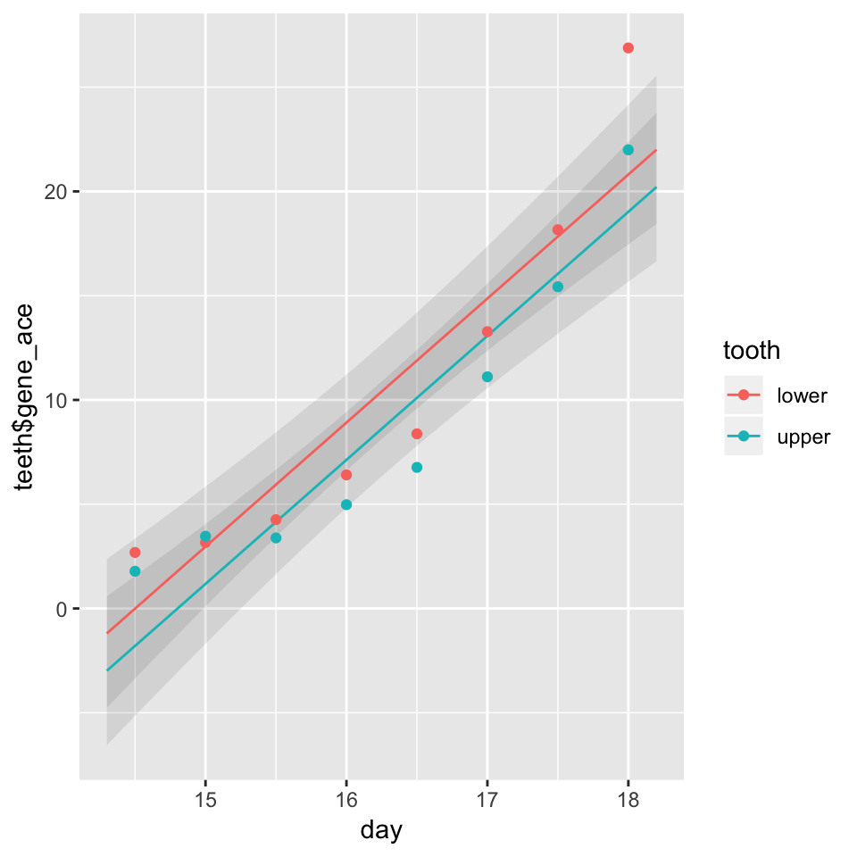

```r
acefit <- lm(gene_ace ~ tooth + day, data=teeth)

look(teeth$gene_ace, acefit)
```

Two problems:

1. The actual data appears to be curved, our straight lines are not a good fit.
2. The predictions fall below zero, a physical impossibility.

In this case, log transformation of the data will solve both these problems.

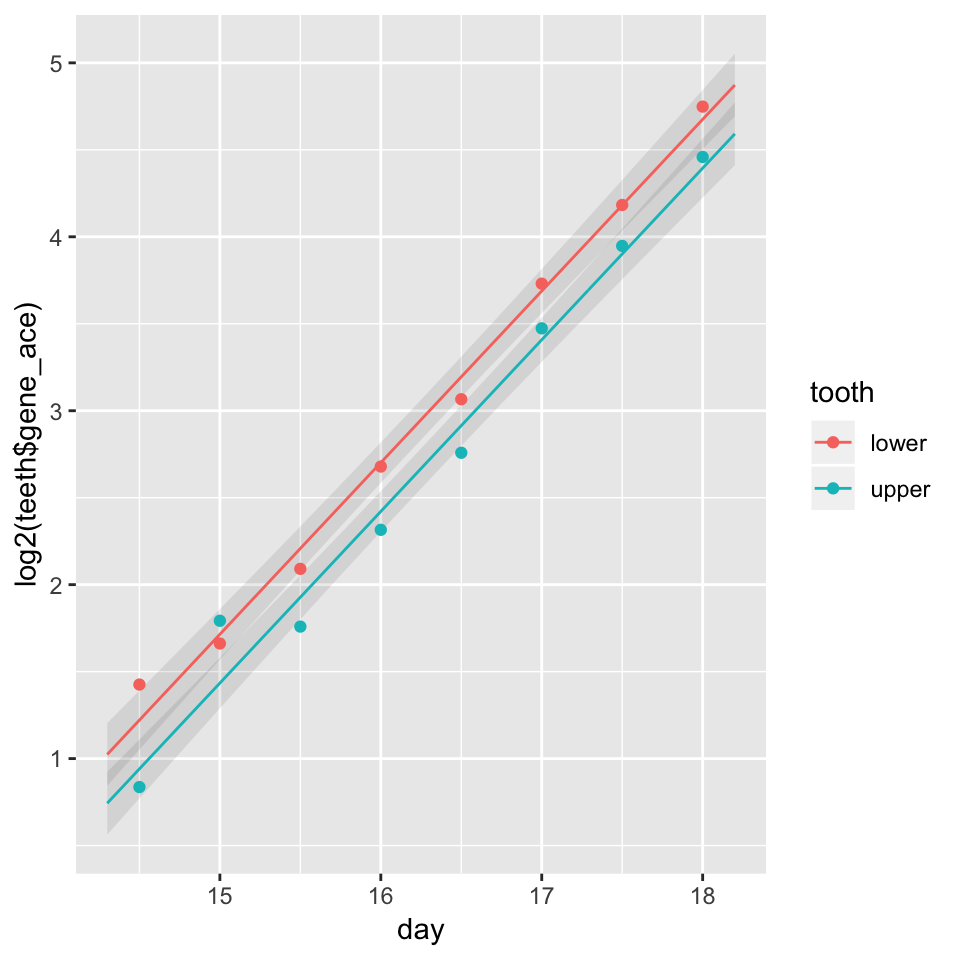

```r
log2_acefit <- lm( log2(gene_ace) ~ tooth+day, data=teeth)

look(log2(teeth$gene_ace), log2_acefit)
```

Various transformations of y are possible. Log transformation is commonly used in the context of gene expression. Square root transformation can also be appropriate with nicely behaved count data (technically, if the errors follow a Poisson distribution). This gene expression data is ultimately count based, but is overdispersed compared to the Poisson distribution so square root transformation isn’t appropriate in this case.

### 4.1.2 Pou3f3 gene

In the case of the Pou3f3 gene, the log transformation is even more important. It looks like gene expression changes at different rates in the upper and lower molars, that is there is a significant interaction between `tooth` and `day`.

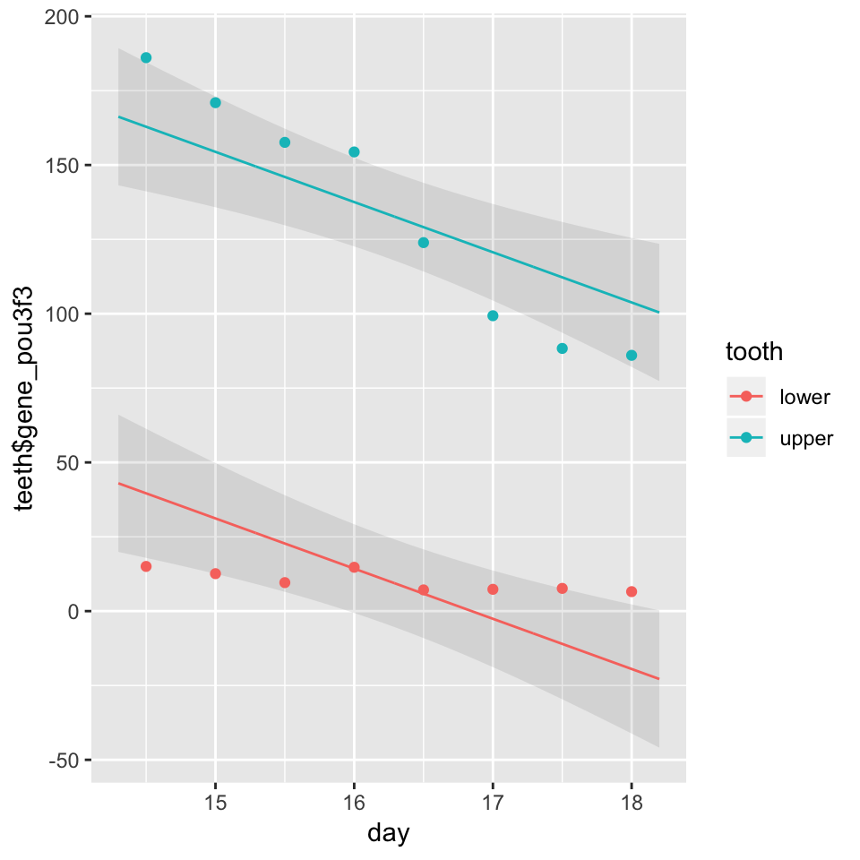

```r
pou3f3fit0 <- lm(gene_pou3f3 ~ tooth+day, data=teeth)
look(teeth$gene_pou3f3, pou3f3fit0)
```

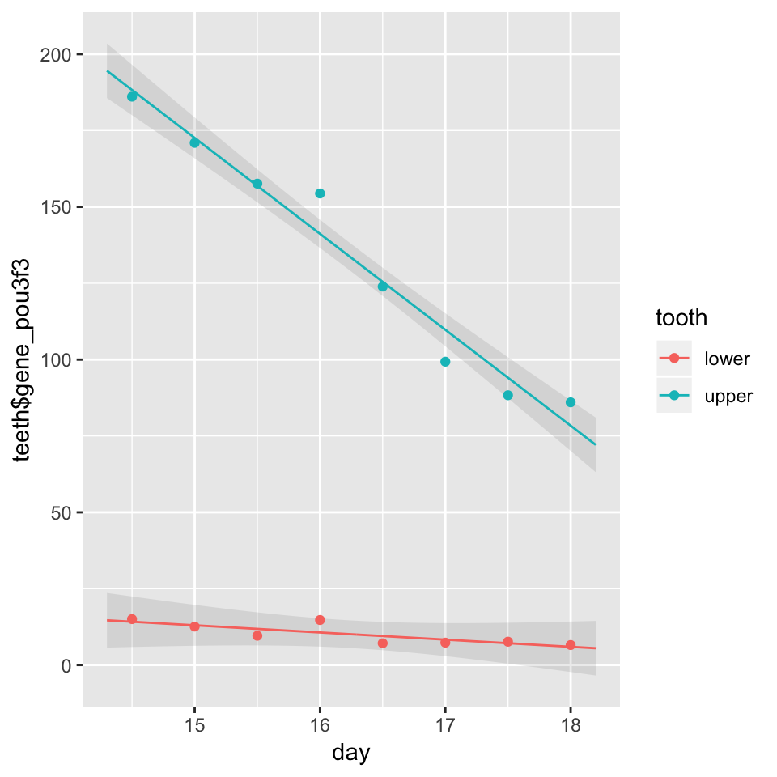

```r
pou3f3fit1 <- lm(gene_pou3f3 ~ tooth*day, data=teeth)
look(teeth$gene_pou3f3, pou3f3fit1)
```

```r
anova(pou3f3fit0, pou3f3fit1)
```

```
## Analysis of Variance Table
##
## Model 1: gene_pou3f3 ~ tooth + day
## Model 2: gene_pou3f3 ~ tooth * day
##   Res.Df    RSS Df Sum of Sq      F    Pr(>F)
## 1     13 4849.7
## 2     12  415.2  1    4434.5 128.15 9.234e-08 ***
## ---
## Signif. codes:  0 '***' 0.001 '**' 0.01 '*' 0.05 '.' 0.1 ' ' 1
```

Examining the residuals reveals a further problem: larger expression values are associated with larger residuals.

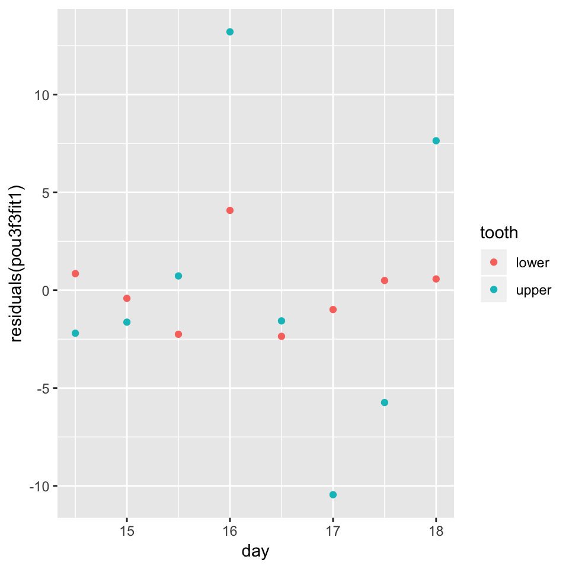

```r
look(residuals(pou3f3fit1))
```

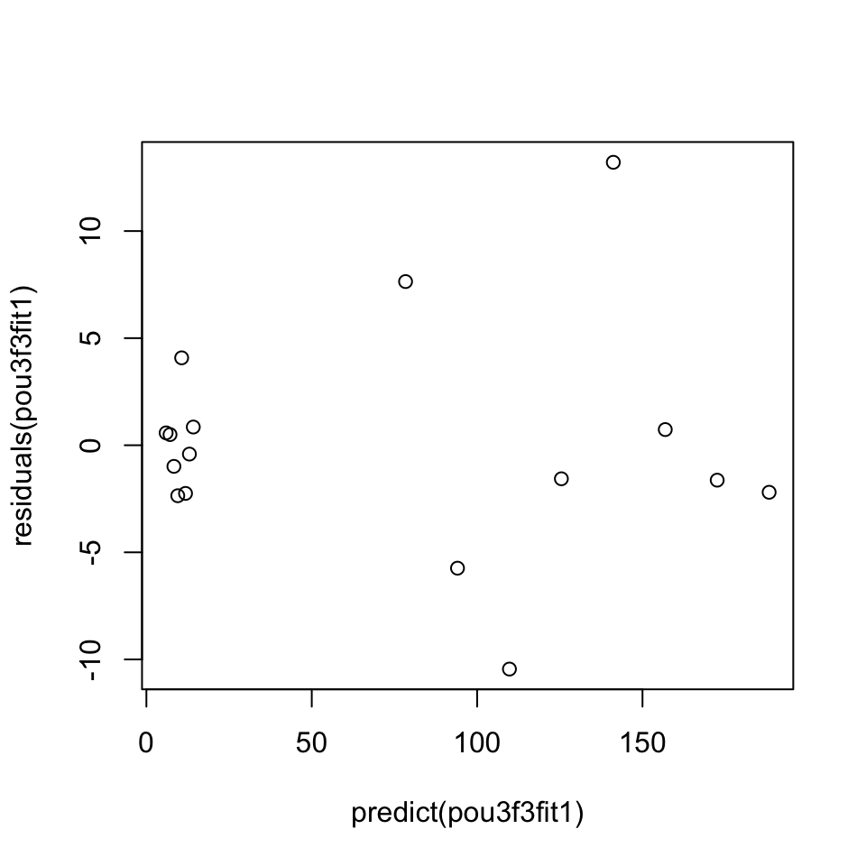

```r
plot(predict(pou3f3fit1), residuals(pou3f3fit1))
```

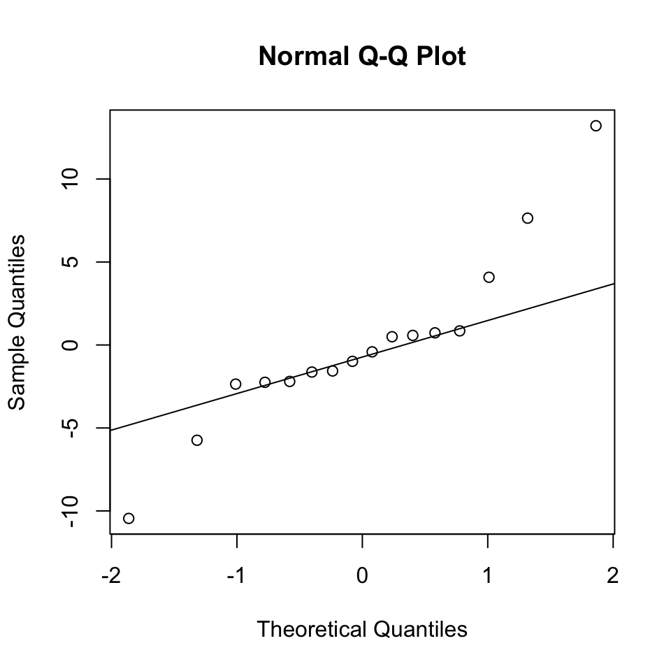

```r
qqnorm(residuals(pou3f3fit1))
qqline(residuals(pou3f3fit1))
```

Log transformation both removes the interaction and makes the residuals more uniform (except for one outlier).

```r
log2_pou3f3fit0 <- lm(log2(gene_pou3f3) ~ tooth+day, data=teeth)
log2_pou3f3fit1 <- lm(log2(gene_pou3f3) ~ tooth*day, data=teeth)

anova(log2_pou3f3fit0, log2_pou3f3fit1)
```

```
## Analysis of Variance Table
##
## Model 1: log2(gene_pou3f3) ~ tooth + day
## Model 2: log2(gene_pou3f3) ~ tooth * day
##   Res.Df     RSS Df Sum of Sq      F Pr(>F)
## 1     13 0.56714
## 2     12 0.56579  1 0.0013576 0.0288 0.8681
```

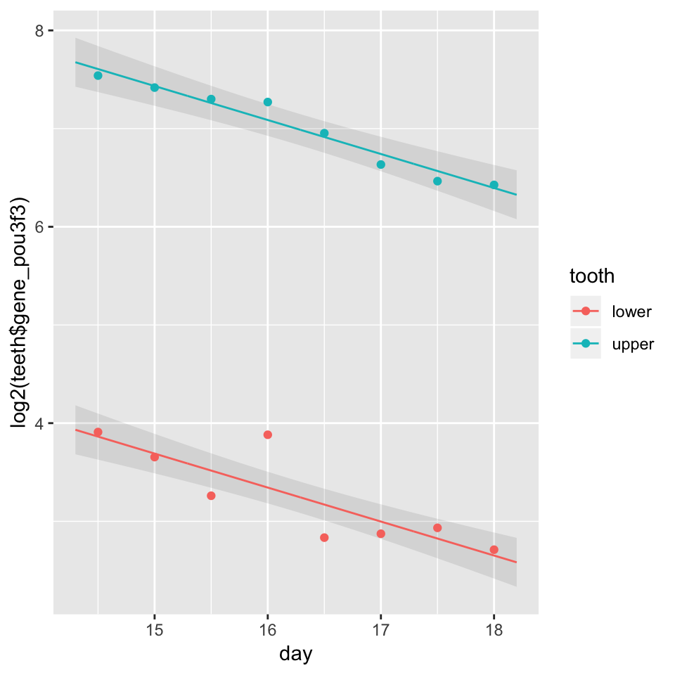

```r
look(log2(teeth$gene_pou3f3), log2_pou3f3fit0)
```

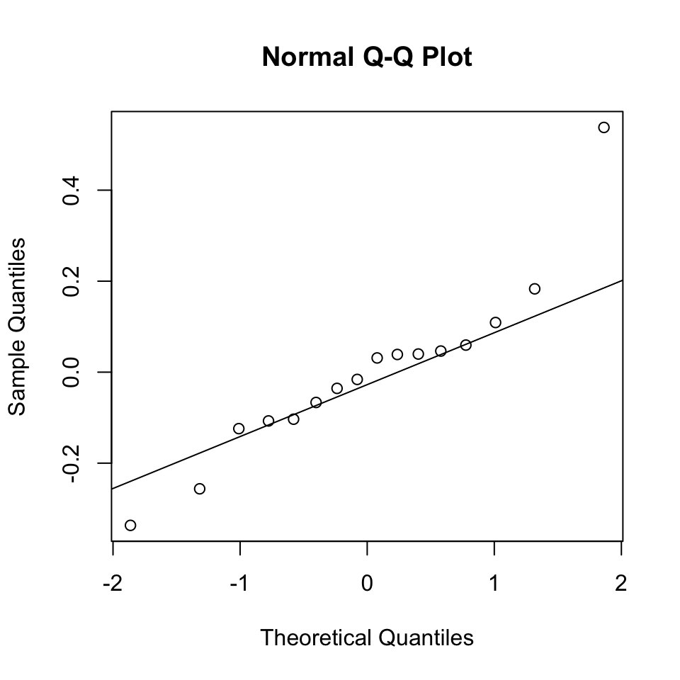

```r
qqnorm(residuals(log2_pou3f3fit0))
qqline(residuals(log2_pou3f3fit0))
```

## 4.2 Homework - Wnt2 gene

Look at the expression of gene Wnt2 in column `gene_wnt2`.

1. Try some different model formulas.
2. Justify a particular model by rejecting simpler alternatives using `anova( )`. For example, can we reject that there is no interaction between tooth and day?

# 5 Testing many genes with limma

In this section we look at fitting the same matrix of predictors X to many different sets of responses y. We will use the package `limma` from Bioconductor. This is a very brief demonstration, and there is much more to this package. See the excellent usersguide.pdf at https://bioconductor.org/packages/release/bioc/html/limma.html

## 5.1 Load, normalize, log transform

Actually in the teeth dataset, the expression level of all genes was measured!

```r
counts_df <- read_csv("data/linearModels/teeth-read-counts.csv")
counts <- as.matrix(counts_df[,-1])
rownames(counts) <- counts_df[[1]]

dim(counts)
```

```
## [1] 32544    16
```

```r
counts[1:5,]
```

```
##               ind1lower ind1upper ind2lower ind2upper ind3lower ind3upper
## 0610007P14Rik      1721      1846      1708      1877      1443      1534
## 0610009B22Rik       512       466       554       504       501       498
## 0610009L18Rik        68        71       121       129        74       124
## 0610009O20Rik      2583      2797      2840      2975      2675      2690
## 0610010F05Rik      1079      1246      1262       992      1232       992
##               ind4lower ind4upper ind5lower ind5upper ind6lower ind6upper
## 0610007P14Rik      1389      1439      1699      1881      1697      1716
## 0610009B22Rik       478       427       569       614       577       568
## 0610009L18Rik        83        87        86       125        99       135
## 0610009O20Rik      2429      2313      2693      3093      2854      3066
## 0610010F05Rik      1011       977      1175      1384      1235      1221
##               ind7lower ind7upper ind8lower ind8upper
## 0610007P14Rik      1531      1625      1716      1373
## 0610009B22Rik       587       531       611       453
## 0610009L18Rik       130       132       114        92
## 0610009O20Rik      2487      2904      2713      2455
## 0610010F05Rik      1042       998      1079       882
```

The column names match our `teeth` data frame.

```r
teeth$sample
```

```
##  [1] "ind1lower" "ind1upper" "ind2lower" "ind2upper" "ind3lower"
##  [6] "ind3upper" "ind4lower" "ind4upper" "ind5lower" "ind5upper"
## [11] "ind6lower" "ind6upper" "ind7lower" "ind7upper" "ind8lower"
## [16] "ind8upper"
```

A usual first step in RNA-Seq analysis is to convert read counts to Reads Per Million, and log2 transform the results. There are some subtleties here which we breeze over lightly: “TMM” normalization is used as a small adjustment to the total number of reads in each sample. A small constant is added to the counts to avoid calculating `log2(0)`. The `edgeR` and `limma` manuals describe these steps in more detail.

```r
library(edgeR)
library(limma)

dgelist <- calcNormFactors(DGEList(counts))

dgelist$samples
```

```
##           group lib.size norm.factors
## ind1lower     1 37902941    0.9941578
## ind1upper     1 39786308    1.0028804
## ind2lower     1 43133654    0.9984159
## ind2upper     1 40974683    0.9950708
## ind3lower     1 41135198    1.0000633
## ind3upper     1 39615728    1.0011691
## ind4lower     1 37762217    0.9974437
## ind4upper     1 36832933    1.0048675
## ind5lower     1 41669201    1.0037162
## ind5upper     1 49717562    0.9967401
## ind6lower     1 44203546    1.0008790
## ind6upper     1 45924751    1.0041814
## ind7lower     1 39920915    1.0071850
## ind7upper     1 42882436    1.0131047
## ind8lower     1 44664204    0.9855638
## ind8upper     1 40780553    0.9948624
```

```r
log2_cpms <- cpm(dgelist, log=TRUE, prior.count=0.25)
```

There is little chance of detecting differential expression in genes with very low read counts. Including these genes will require a larger False Discovery Rate correction, and also confuses limma’s Empirical Bayes parameter estimation. Let’s only retain genes with around 5 reads per sample or more.

```r
keep <- rowMeans(log2_cpms) >= -3
log2_cpms_filtered <- log2_cpms[keep,]

nrow(log2_cpms)
```

```
## [1] 32544
```

```r
nrow(log2_cpms_filtered)
```

```
## [1] 17184
```

## 5.2 Fitting a model to and testing each gene

We use limma to fit a linear model to each gene. The same model formula will be used in each case. limma doesn’t automatically convert a formula into a model matrix, so we have to do this step manually. Here I am using a model formula that treats the upper and lower teeth as following a different linear trend over time.

```r
X <- model.matrix(~ tooth*day, data=teeth)
X
```

```
##    (Intercept) toothupper  day toothupper:day
## 1            1          0 14.5            0.0
## 2            1          1 14.5           14.5
## 3            1          0 15.0            0.0
## 4            1          1 15.0           15.0
## 5            1          0 15.5            0.0
## 6            1          1 15.5           15.5
## 7            1          0 16.0            0.0
## 8            1          1 16.0           16.0
## 9            1          0 16.5            0.0
## 10           1          1 16.5           16.5
## 11           1          0 17.0            0.0
## 12           1          1 17.0           17.0
## 13           1          0 17.5            0.0
## 14           1          1 17.5           17.5
## 15           1          0 18.0            0.0
## 16           1          1 18.0           18.0
## attr(,"assign")
## [1] 0 1 2 3
## attr(,"contrasts")
## attr(,"contrasts")$tooth
## [1] "contr.treatment"
```

```r
fit <- lmFit(log2_cpms_filtered, X)

class(fit)
```

```
## [1] "MArrayLM"
## attr(,"package")
## [1] "limma"
```

```r
fit$coefficients[1:5,]
```

```
##               (Intercept) toothupper         day toothupper:day
## 0610007P14Rik   5.8166503  1.3602289 -0.03253986    -0.08309585
## 0610009B22Rik   3.1429659  0.6444600  0.03628325    -0.04855614
## 0610009L18Rik  -0.9210806  1.5433085  0.13073928    -0.08390279
## 0610009O20Rik   6.6202820  0.2793953 -0.03744979    -0.01505784
## 0610010F05Rik   5.8290439  0.2983386 -0.06415423    -0.02496738
```

Significance testing in limma is by the use of linear hypotheses (which limma refers to as “contrasts”). A difference between `glht` and limma’s `contrasts.fit` is that limma expects the contrasts in columns rather than rows.

We will first look for genes where the slope over time is not flat, *averaging* the lower and upper teeth.

```r
# Lower slope: c(0,0,1,0)
# Upper slope: c(0,0,1,1)

K <- rbind(c(0,0,1,0.5))
cfit <- contrasts.fit(fit, t(K))       #linear hypotheses in columns!
efit <- eBayes(cfit, trend=TRUE)
```

The call to `eBayes` does Emprical Bayes squeezing of the residual variance for each gene (see final section). This is a bit of magic that allows limma to work well with small numbers of samples.

```r
topTable(efit)
```

```
##              logFC  AveExpr         t      P.Value    adj.P.Val        B
## Rnf144b  0.6691463 4.482150  33.59773 8.443061e-16 1.450856e-11 25.92108
## Six2    -0.5596996 6.978090 -29.65927 5.575830e-15 3.897189e-11 24.30201
## Tfap2b  -0.6436429 7.468218 -29.10993 7.395514e-15 3.897189e-11 24.05339
## Prom2    0.9160517 3.673827  28.71874 9.071668e-15 3.897189e-11 23.87259
## Ace      0.9868018 2.807906  27.99265 1.335035e-14 4.588250e-11 23.52847
## Vldlr    0.4128294 6.813937  27.62111 1.633011e-14 4.676943e-11 23.34794
## Stk32a   1.2264479 3.705238  27.22394 2.031340e-14 4.986650e-11 23.15153
## Bambi    0.5594820 6.103750  26.42243 3.185674e-14 6.842827e-11 22.74397
## Msx2     0.8109292 6.252888  25.19599 6.508960e-14 1.176579e-10 22.08980
## Igf2bp1 -0.5403002 5.915267 -25.11120 6.846944e-14 1.176579e-10 22.04313
```

The column `adj.P.Val` contains FDR adjusted p-values.

```r
all_results <- topTable(efit, n=Inf)

significant <- all_results$adj.P.Val <= 0.05
table(significant)
```

```
## significant
## FALSE  TRUE
## 10471  6713
```

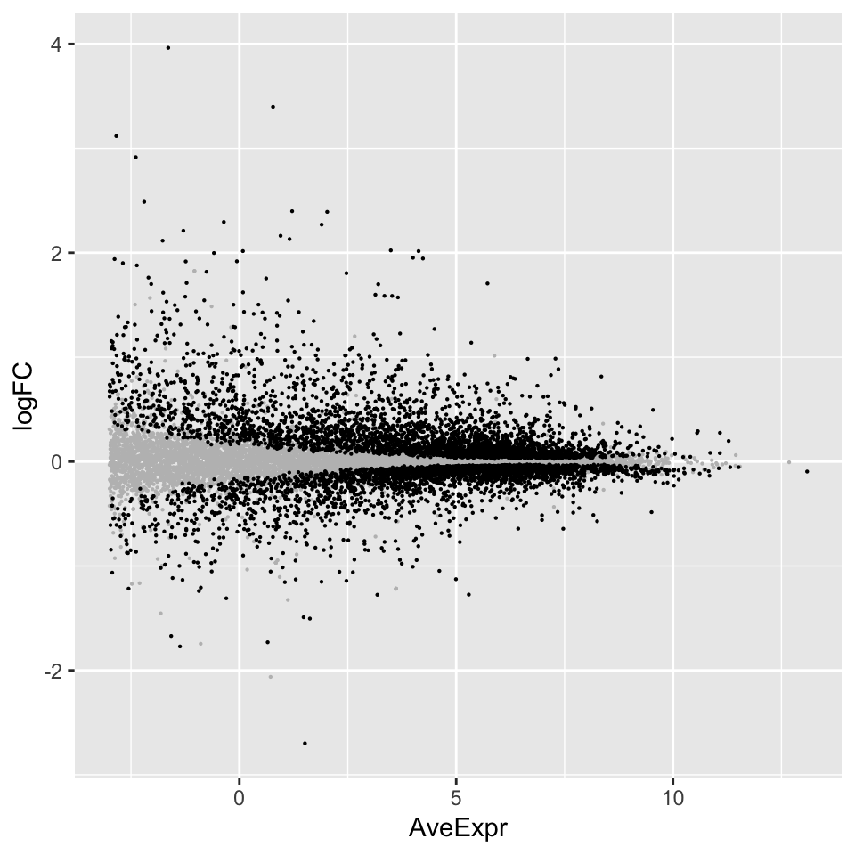

```r
ggplot(all_results, aes(x=AveExpr, y=logFC)) +
    geom_point(size=0.1, color="grey") +
    geom_point(data=all_results[significant,], size=0.1)
```

## 5.3 Relation to lm( ) and glht( )

Let’s look at a specific gene.

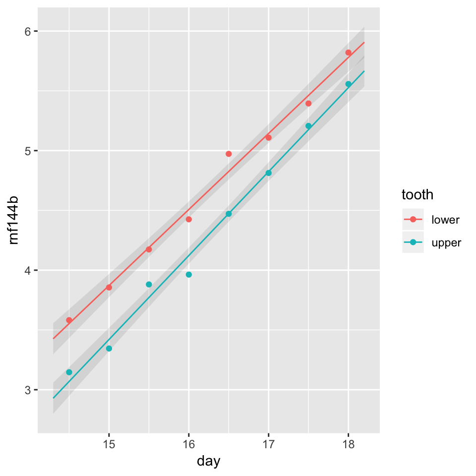

```r
rnf144b <- log2_cpms["Rnf144b",]
rnf144b_fit <- lm(rnf144b ~ tooth * day, data=teeth)
look(rnf144b, rnf144b_fit)
```

We can use the same linear hypothesis with `glht`. The estimate is the same, but limma has gained some power by shrinking the variance toward the trend line, so limma’s p-value is smaller.

```r
summary( glht(rnf144b_fit, K) )
```

```
##
##   Simultaneous Tests for General Linear Hypotheses
##
## Fit: lm(formula = rnf144b ~ tooth * day, data = teeth)
##
## Linear Hypotheses:
##        Estimate Std. Error t value Pr(>|t|)
## 1 == 0   0.6692     0.0187   35.78 1.45e-13 ***
## ---
## Signif. codes:  0 '***' 0.001 '**' 0.01 '*' 0.05 '.' 0.1 ' ' 1
## (Adjusted p values reported -- single-step method)
```

## 5.4 Confidence intervals

Confidence Intervals should also be of interest. However note that these are not adjusted for multiple testing (see final section).

```r
topTable(efit, confint=0.95)
```

```
##              logFC       CI.L       CI.R  AveExpr         t      P.Value
## Rnf144b  0.6691463  0.6267819  0.7115106 4.482150  33.59773 8.443061e-16
## Six2    -0.5596996 -0.5998402 -0.5195591 6.978090 -29.65927 5.575830e-15
## Tfap2b  -0.6436429 -0.6906748 -0.5966109 7.468218 -29.10993 7.395514e-15
## Prom2    0.9160517  0.8482026  0.9839007 3.673827  28.71874 9.071668e-15
## Ace      0.9868018  0.9118167  1.0617869 2.807906  27.99265 1.335035e-14
## Vldlr    0.4128294  0.3810374  0.4446215 6.813937  27.62111 1.633011e-14
## Stk32a   1.2264479  1.1306211  1.3222747 3.705238  27.22394 2.031340e-14
## Bambi    0.5594820  0.5144416  0.6045225 6.103750  26.42243 3.185674e-14
## Msx2     0.8109292  0.7424686  0.8793898 6.252888  25.19599 6.508960e-14
## Igf2bp1 -0.5403002 -0.5860676 -0.4945327 5.915267 -25.11120 6.846944e-14
##            adj.P.Val        B
## Rnf144b 1.450856e-11 25.92108
## Six2    3.897189e-11 24.30201
## Tfap2b  3.897189e-11 24.05339
## Prom2   3.897189e-11 23.87259
## Ace     4.588250e-11 23.52847
## Vldlr   4.676943e-11 23.34794
## Stk32a  4.986650e-11 23.15153
## Bambi   6.842827e-11 22.74397
## Msx2    1.176579e-10 22.08980
## Igf2bp1 1.176579e-10 22.04313
```

## 5.5 F test

limma can also test several simultaneous constraints on linear combinations of coefficients. Suppose we want to find *any* deviation from a constant expression level. We can check for this with:

```r
K2 <- rbind(
    c(0,1,0,0),
    c(0,0,1,0),
    c(0,0,0,1))

cfit2 <- contrasts.fit(fit, t(K2))
efit2 <- eBayes(cfit2, trend=TRUE)
topTable(efit2)
```

```
##              Coef1      Coef2       Coef3  AveExpr        F      P.Value
## Pou3f3   4.0047206 -0.3380707 -0.01608095 5.129071 504.0972 1.484696e-15
## Six2    -0.7942430 -0.6091343  0.09886927 6.978090 413.1779 6.717734e-15
## Rnf144b -1.4417453  0.6361262  0.06604010 4.482150 398.9320 8.764172e-15
## Tfap2b  -4.3123192 -0.7918207  0.29635558 7.468218 330.3518 3.652672e-14
## Prom2    0.6123007  0.9616841 -0.09126493 3.673827 322.9195 4.337796e-14
## Vldlr    2.2398523  0.4745006 -0.12334239 6.813937 275.7521 1.427338e-13
## Ace     -0.4928863  0.9802659  0.01307194 2.807906 265.2266 1.913299e-13
## Stk32a   0.8858069  1.2654438 -0.07799180 3.705238 251.8520 2.823707e-13
## Bambi    1.5850479  0.6165574 -0.11415072 6.103750 245.4526 3.426369e-13
## Ptprt    3.5394970  0.8807989 -0.18751019 3.087069 216.1003 8.909622e-13
##            adj.P.Val
## Pou3f3  2.551301e-11
## Six2    5.020118e-11
## Rnf144b 5.020118e-11
## Tfap2b  1.490814e-10
## Prom2   1.490814e-10
## Vldlr   4.087896e-10
## Ace     4.696876e-10
## Stk32a  6.065323e-10
## Bambi   6.542081e-10
## Ptprt   1.388992e-09
```

A shortcut would be to use `contrasts.fit(fit, coefficients=2:4)` here instead, or to specify a set of coefficients directly to `topTable( )`. The results would be the same.

## 5.6 Homework - construct some linear hypotheses

Construct and use linear combinations of coefficients to find genes that:

1. Differ in slope between lower and upper molars.
2. Differ in expression on day 16 between the lower and upper molars.

Hint: the null hypothesis for 2 can be specified as saying the difference in predictions between two particular samples is zero.

3. Construct a pair of linear combinations that when used together in an F test find genes with non-zero slope in either or both of the lower and upper molars.

# 6 Fitting curves

Not all of the genes in our teeth data have a straight line relationship with time. Returning to the original data frame, let’s look at the Smoc1 gene.

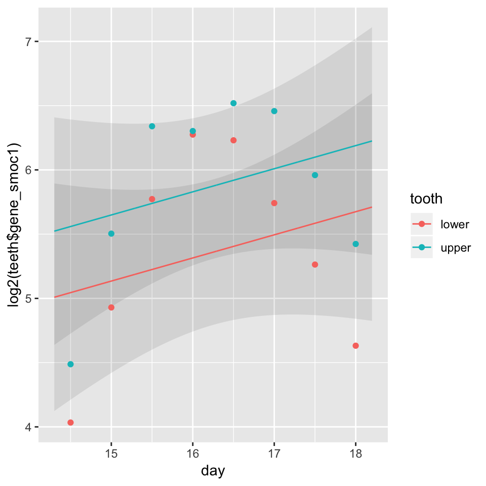

```r
log2_smoc1fit <- lm(log2(gene_smoc1) ~ tooth + day, data=teeth)

look(log2(teeth$gene_smoc1), log2_smoc1fit)
```

In this case, log transformation does not remove the curve. If you think this is a problem for *linear* models, you are mistaken! With a little *feature engineering* we can fit a quadratic curve. Calculations can be included in the formula if wrapped in `I( )`:

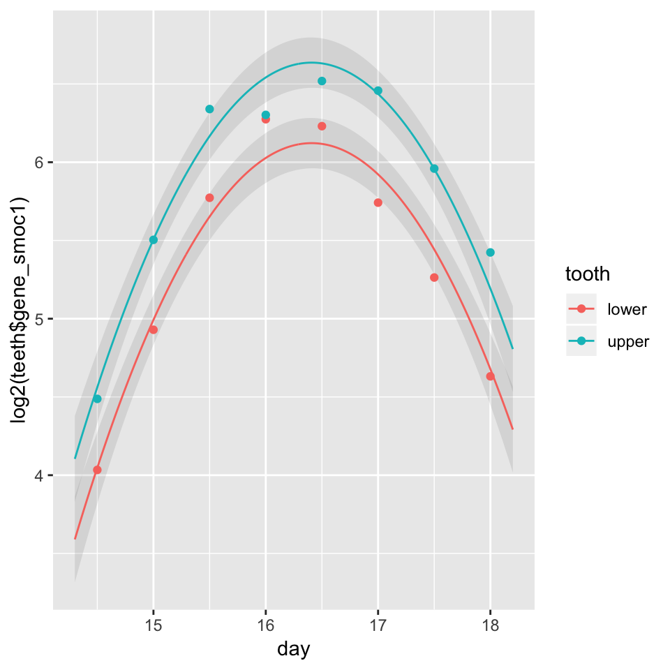

```r
curved_fit <- lm(log2(gene_smoc1) ~ tooth + day + I(day^2), data=teeth)
look(log2(teeth$gene_smoc1), curved_fit)
```

Another way to do this would be to add the column to the data frame:

```r
teeth$day_squared <- teeth$day^2
curved_fit2 <- lm(log2(gene_smoc1) ~ tooth + day + day_squared, data=teeth)
```

Finally, the `poly( )` function can be used in a formula to fit polynomials of arbitrary degree. `poly` will encode `day` slightly differently, but produces an equivalent fit.

```r
curved_fit3 <- lm(log2(gene_smoc1) ~ tooth + poly(day,2), data=teeth)
```

```r
sigma(curved_fit)
```

```
## [1] 0.1630425
```

```r
sigma(curved_fit2)
```

```
## [1] 0.1630425
```

```r
sigma(curved_fit3)
```

```
## [1] 0.1630425
```

`poly( )` can also be used to fit higher order polynomials, but these tend to become wobbly and extrapolate poorly. A better option may be to use the `ns( )` or `bs( )` functions in the `splines` package, which can be used to fit piecewise “B-splines”. In particular `ns( )` (natural spline) is appealing because it extrapolates beyond the ends only with straight lines. If the data is cyclic (for example cell cycle or circadian time series), sine and cosine terms can be used to fit some number of harmonics from a Fourier series.

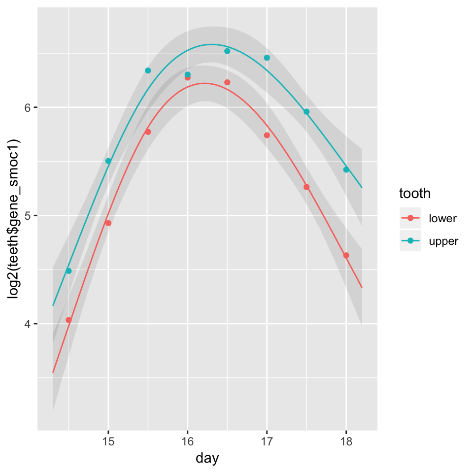

```r
library(splines)
spline_fit <- lm(log2(gene_smoc1) ~ tooth * ns(day,3), data=teeth)

look(log2(teeth$gene_smoc1), spline_fit)
```

All of these approaches can also be used with limma (or edgeR or DESeq2).

# 7 Some further details on limma

## 7.1 Empirical Bayes variance squeezing

In limma, Empirical Bayes squeezing of the residual variance acts as though we have some number of extra “prior” observations of the variance. These are also counted as extra degrees of freedom in F tests. The “prior” observations act to squeeze the estimated residual variance of each gene toward a trend line that is a function of the average expression level. (There is also an alternative approach that estimates variance at the level of individual observations rather than genes, called `voom`.)

```r
efit <- eBayes(cfit, trend=TRUE)

efit$df.prior
```

```
## [1] 3.360083
```

```r
efit$df.residual
```

```
##  [1] 12 12 12 12 12 12 12 12 12 12 12 12 12 12 12 12 12 12 12 12 12
##  [ reached getOption("max.print") -- omitted 17163 entries ]
```

```r
efit$df.total
```

```
##  [1] 15.36008 15.36008 15.36008 15.36008 15.36008 15.36008 15.36008
##  [8] 15.36008 15.36008 15.36008 15.36008 15.36008 15.36008 15.36008
## [15] 15.36008 15.36008 15.36008 15.36008 15.36008 15.36008 15.36008
##  [ reached getOption("max.print") -- omitted 17163 entries ]
```

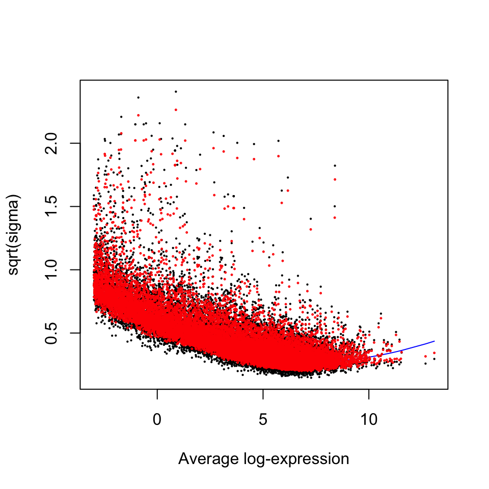

```r
plotSA(efit)
points(efit$Amean, efit$s2.post^0.25, col="red", cex=0.2)
```

The total effective degrees of freedom is the “prior” degrees of freedom plus the normal residual degrees of freedom. As can be seen in the plot, compared to the residual variance (black dots), this produces a posterior residual variance (`efit$s2.post`, red dots) that is squeezed toward the trend line.

It’s worthwhile checking `df.prior` when using limma, as a low value may indicate a problem with a data-set.

## 7.2 False Coverage-statement Rate corrected CIs

We noted the CIs produced by limma were not adjusted for multiple testing. A False Coverage-statement Rate (FCR) corrected CI can be constructed corresponding to a set of genes judged significant. The smaller the selection of genes as a proportion of the whole, the greater the correction required. To ensure a False Coverage-statement Rate of q, we need `(1-q*n_genes_selected/n_genes_total)*100%` confidence intervals.

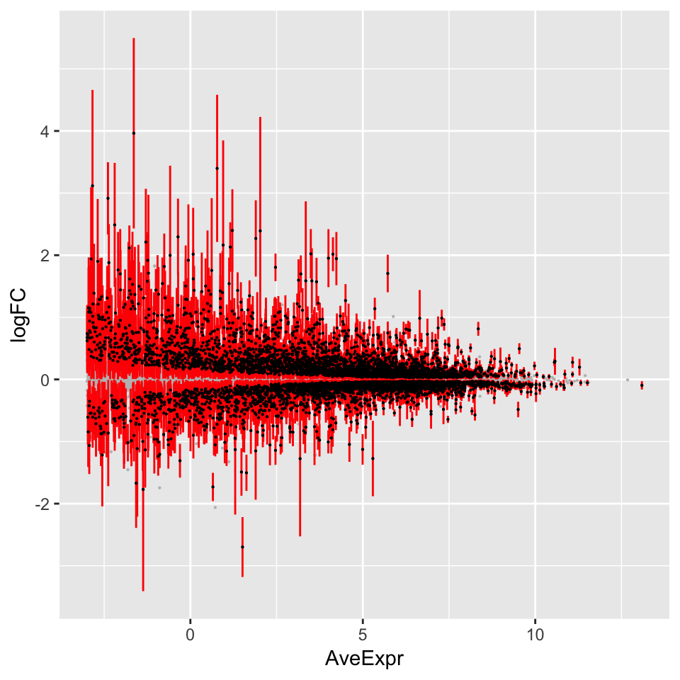

```r
all_results <- topTable(efit, n=Inf)
significant <- all_results$adj.P.Val <= 0.05
prop_significant <- mean(significant)
fcr_confint <- 1 - 0.05*prop_significant

all_results <- topTable(efit, confint=fcr_confint, n=Inf)

ggplot(all_results, aes(x=AveExpr, y=logFC)) +
    geom_point(size=0.1, color="grey") +
    geom_errorbar(data=all_results[significant,], aes(ymin=CI.L, ymax=CI.R), color="red") +
    geom_point(data=all_results[significant,], size=0.1)
```

The FCR corrected CIs used here have the same q, 0.05, as we used as the cutoff for adj.P.Val. This means they never pass through zero.

I have some further thoughts on this topic, see the package `topconfects` (http://logarithmic.net/topconfects/).

Home